# Desigualdades Educacionais: Amazônia Legal vs. Restante do Brasil

Análise Comparativa do IDEB 2005-2023 - Rede Pública

# Introdução

Este relatório apresenta uma análise comparativa do **Índice de Desenvolvimento da Educação Básica (IDEB)** entre a **Amazônia Legal** e o **restante do Brasil**, utilizando os dados oficiais de divulgação do INEP referentes ao período **2005 a 2023**. O IDEB é o principal indicador de qualidade da educação básica no Brasil, calculado a partir de dois componentes: a **nota padronizada do SAEB** (Nota N, que combina proficiência em Matemática e Língua Portuguesa) e o **indicador de rendimento** (Fluxo P, derivado das taxas de aprovação).

A análise abrange três etapas de ensino: **Anos Iniciais do Ensino Fundamental** (1º ao 5º ano), **Anos Finais do Ensino Fundamental** (6º ao 9º ano) e **Ensino Médio**. Para cada etapa, são utilizados dados em nível **municipal** (agregados por rede) e em nível de **escola**, totalizando seis bases de dados do INEP.

A delimitação da Amazônia Legal foi feita **no nível municipal**, utilizando a classificação oficial do IBGE com **772 municípios** distribuídos em 9 UFs (AC, AM, AP, MA, MT, PA, RO, RR, TO). Apenas dados da **rede pública** (municipal, estadual e federal) foram considerados, excluindo-se a rede privada.

```
## Municípios classificados como Amazônia Legal: 772
```

```
## Registros municipais - Anos Iniciais: 14514
```

```
## Registros municipais - Anos Finais: 14417
```

```
## Registros municipais - Ensino Médio: 11735
```

```
## Registros escolares - Anos Iniciais: 64921
```

```
## Registros escolares - Anos Finais: 47235
```

```
## Registros escolares - Ensino Médio: 20345
```

# IDEB Observado 2023

## Panorama Geral

Tabela 1 - IDEB Observado 2023: Médias por etapa e região (rede pública municipal e estadual)

| Etapa | IDEB Médio Média AL | IDEB Médio Média RB | IDEB Médio Diferença | IDEB Mediano Mediana AL | IDEB Mediano Mediana RB | Dispersão D.P. AL | Dispersão D.P. RB | Municípios N AL | Municípios N RB | Comparação |
| --- | --- | --- | --- | --- | --- | --- | --- | --- | --- | --- |
| Anos Iniciais | 5,09 | 5,95 | ▼ -0,86 | 5,00 | 6,00 | 0,75 | 0,90 | 911 | 5.520 |  |
| Anos Finais | 4,39 | 4,83 | ▼ -0,44 | 4,40 | 4,90 | 0,59 | 0,77 | 918 | 5.831 |  |
| Ensino Médio | 3,84 | 4,20 | ▼ -0,36 | 3,90 | 4,20 | 0,46 | 0,55 | 743 | 4.360 |  |

**Legenda:** ■ Amazônia Legal ■ Restante do Brasil. Setas indicam a direção da diferença: ▲ AL acima, ▼ AL abaixo.

## Por Rede de Ensino

Tabela 2 - IDEB 2023 por rede de ensino e região

| Etapa | Rede | Média AL | Média RB | Diferença | Mediana AL | Mediana RB | N AL | N RB | Comparação |
| --- | --- | --- | --- | --- | --- | --- | --- | --- | --- |
| **Anos Iniciais** |  |  |  |  |  |  |  |  |  |
| Anos Iniciais | Estadual | 5,56 | 6,08 | ▼ -0,52 | 5,60 | 6,10 | 163 | 1.027 |  |
| Anos Iniciais | Municipal | 4,98 | 5,92 | ▼ -0,94 | 5,00 | 6,00 | 748 | 4.493 |  |
| **Anos Finais** |  |  |  |  |  |  |  |  |  |
| Anos Finais | Estadual | 4,61 | 4,98 | ▼ -0,37 | 4,60 | 5,00 | 463 | 3.091 |  |
| Anos Finais | Municipal | 4,17 | 4,66 | ▼ -0,49 | 4,20 | 4,70 | 455 | 2.740 |  |
| **Ensino Médio** |  |  |  |  |  |  |  |  |  |
| Ensino Médio | Estadual | 3,84 | 4,20 | ▼ -0,36 | 3,90 | 4,20 | 740 | 4.323 |  |
| Ensino Médio | Municipal | 4,43 | 4,39 | ▲ +0,04 | 4,50 | 4,50 | 3 | 37 |  |

## Por UF

Tabela 3 - IDEB 2023 por UF: Anos Iniciais (rede pública)

| UF | Média IDEB | Mediana IDEB | Diferença vs. RB | Municípios | Comparação |
| --- | --- | --- | --- | --- | --- |
| AP | 4,30 | 4,15 | ▼ -1,65 | 20 |  |
| RR | 4,66 | 4,60 | ▼ -1,29 | 13 |  |
| PA | 4,69 | 4,65 | ▼ -1,26 | 160 |  |
| AM | 4,90 | 4,80 | ▼ -1,05 | 117 |  |
| TO | 4,98 | 5,00 | ▼ -0,97 | 148 |  |
| MA | 5,00 | 4,90 | ▼ -0,95 | 182 |  |
| AC | 5,35 | 5,30 | ▼ -0,60 | 32 |  |
| RO | 5,46 | 5,60 | ▼ -0,49 | 65 |  |
| MT | 5,69 | 5,75 | ▼ -0,26 | 174 |  |
| Restante do Brasil | 5,95 | 6,00 | ● +0,00 | 5.520 |  |

Tabela 4 - IDEB 2023 por UF: Anos Finais (rede pública)

| UF | Média IDEB | Mediana IDEB | Diferença vs. RB | Municípios | Comparação |
| --- | --- | --- | --- | --- | --- |
| RR | 3,83 | 3,80 | ▼ -0,99 | 13 |  |
| AP | 3,88 | 3,85 | ▼ -0,95 | 18 |  |
| PA | 4,12 | 4,10 | ▼ -0,70 | 169 |  |
| AM | 4,24 | 4,30 | ▼ -0,58 | 110 |  |
| MA | 4,29 | 4,20 | ▼ -0,54 | 183 |  |
| AC | 4,33 | 4,50 | ▼ -0,49 | 28 |  |
| TO | 4,48 | 4,50 | ▼ -0,34 | 172 |  |
| RO | 4,72 | 4,80 | ▼ -0,11 | 68 |  |
| MT | 4,77 | 4,80 | ▼ -0,06 | 157 |  |
| Restante do Brasil | 4,83 | 4,90 | ● +0,00 | 5.831 |  |

Tabela 5 - IDEB 2023 por UF: Ensino Médio (rede pública)

| UF | Média IDEB | Mediana IDEB | Diferença vs. RB | Municípios | Comparação |
| --- | --- | --- | --- | --- | --- |
| RR | 3,24 | 3,40 | ▼ -0,96 | 13 |  |
| AM | 3,28 | 3,20 | ▼ -0,92 | 61 |  |
| AP | 3,33 | 3,30 | ▼ -0,87 | 13 |  |
| MA | 3,62 | 3,50 | ▼ -0,58 | 174 |  |
| AC | 3,72 | 3,60 | ▼ -0,48 | 21 |  |
| TO | 3,95 | 4,00 | ▼ -0,25 | 134 |  |
| PA | 4,01 | 4,00 | ▼ -0,19 | 144 |  |
| RO | 4,06 | 4,10 | ▼ -0,14 | 51 |  |
| MT | 4,16 | 4,20 | ▼ -0,04 | 132 |  |
| Restante do Brasil | 4,20 | 4,20 | ● +0,00 | 4.360 |  |

# Evolução Histórica do IDEB

## Série Histórica (Médias)

Tabela 6 - Evolução do IDEB: Anos Iniciais (rede pública municipal e estadual)

| Edição | Média AL | Média RB | Gap | N AL | N RB |
| --- | --- | --- | --- | --- | --- |
| 2005 | 3,14 | 3,69 | ▼ -0,55 | 1.130 | 5.931 |
| 2007 | 3,55 | 4,06 | ▼ -0,51 | 1.215 | 6.840 |
| 2009 | 3,98 | 4,60 | ▼ -0,63 | 1.167 | 6.486 |
| 2011 | 4,25 | 4,94 | ▼ -0,69 | 1.133 | 6.274 |
| 2013 | 4,39 | 5,18 | ▼ -0,79 | 1.067 | 5.903 |
| 2015 | 4,72 | 5,49 | ▼ -0,78 | 1.046 | 5.709 |
| 2017 | 4,95 | 5,73 | ▼ -0,79 | 1.034 | 5.986 |
| 2019 | 5,01 | 5,88 | ▼ -0,87 | 971 | 5.784 |
| 2021 | 4,91 | 5,72 | ▼ -0,81 | 855 | 5.250 |
| 2023 | 5,09 | 5,95 | ▼ -0,86 | 911 | 5.520 |

Tabela 7 - Evolução do IDEB: Anos Finais (rede pública municipal e estadual)

| Edição | Média AL | Média RB | Gap | N AL | N RB |
| --- | --- | --- | --- | --- | --- |
| 2005 | 3,12 | 3,29 | ▼ -0,17 | 947 | 5.926 |
| 2007 | 3,34 | 3,51 | ▼ -0,17 | 1.093 | 6.800 |
| 2009 | 3,60 | 3,75 | ▼ -0,15 | 1.072 | 6.574 |
| 2011 | 3,70 | 3,91 | ▼ -0,21 | 1.029 | 6.398 |
| 2013 | 3,72 | 4,04 | ▼ -0,32 | 991 | 6.314 |
| 2015 | 3,89 | 4,24 | ▼ -0,35 | 946 | 5.956 |
| 2017 | 4,08 | 4,40 | ▼ -0,33 | 966 | 6.304 |
| 2019 | 4,22 | 4,67 | ▼ -0,45 | 878 | 5.841 |
| 2021 | 4,38 | 4,95 | ▼ -0,57 | 711 | 5.041 |
| 2023 | 4,39 | 4,83 | ▼ -0,44 | 918 | 5.831 |

Tabela 8 - Evolução do IDEB: Ensino Médio (rede pública municipal e estadual)

| Edição | Média AL | Média RB | Gap | N AL | N RB |
| --- | --- | --- | --- | --- | --- |
| 2017 | 3,20 | 3,62 | ▼ -0,42 | 743 | 4.624 |
| 2019 | 3,41 | 4,10 | ▼ -0,69 | 635 | 4.181 |
| 2021 | 3,38 | 4,27 | ▼ -0,89 | 411 | 3.005 |
| 2023 | 3,84 | 4,20 | ▼ -0,36 | 743 | 4.360 |

## Gráfico Evolutivo

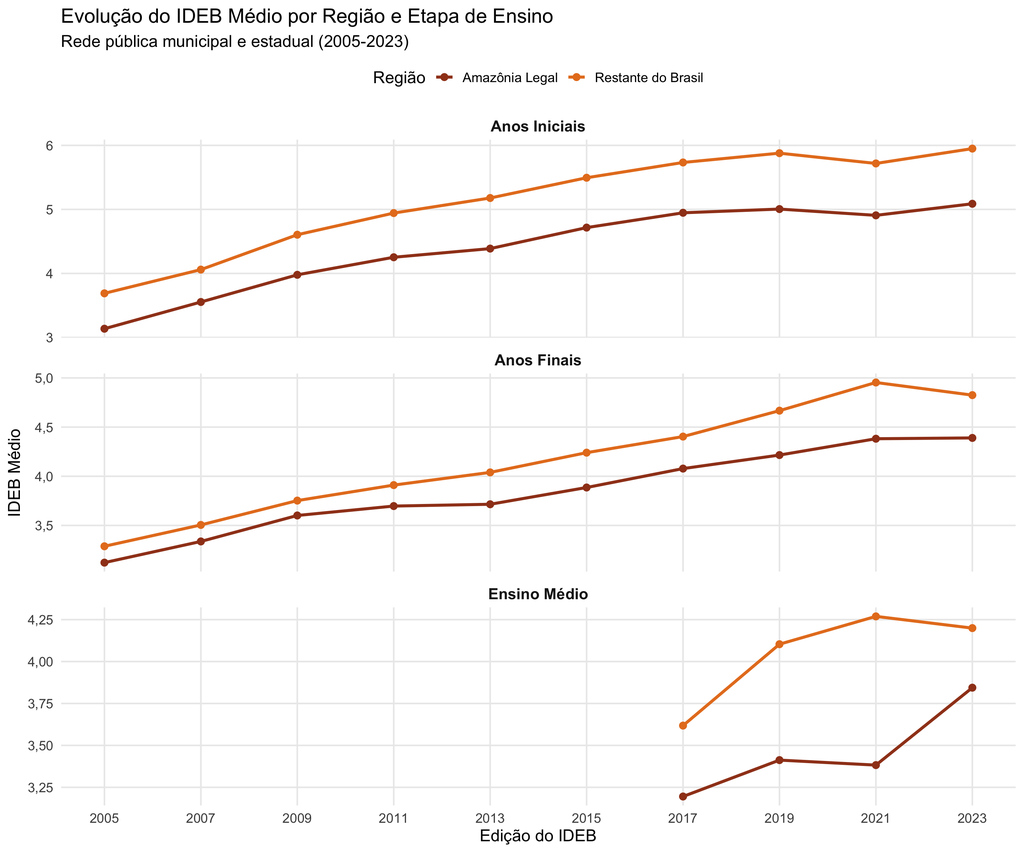

# Componentes do IDEB

## Nota SAEB 2023

Tabela 9 - Notas SAEB 2023 por etapa e região (rede pública)

| Etapa | Matemática Mat. AL | Matemática Mat. RB | Matemática Dif. Mat. | Língua Portuguesa Port. AL | Língua Portuguesa Port. RB | Língua Portuguesa Dif. Port. | Nota Média Padronizada (N) Média N AL | Nota Média Padronizada (N) Média N RB | Nota Média Padronizada (N) Dif. N |
| --- | --- | --- | --- | --- | --- | --- | --- | --- | --- |
| Anos Iniciais | 201,3 | 224,4 | ▼ -23,1 | 191,5 | 212,1 | ▼ -20,5 | 5,29 | 6,10 | ▼ -0,81 |
| Anos Finais | 238,9 | 254,5 | ▼ -15,6 | 241,7 | 255,1 | ▼ -13,4 | 4,68 | 5,16 | ▼ -0,48 |
| Ensino Médio | 253,8 | 269,7 | ▼ -15,9 | 255,4 | 271,7 | ▼ -16,3 | 4,08 | 4,55 | ▼ -0,47 |

## Indicador de Rendimento (Fluxo) 2023

Tabela 10 - Indicador de Rendimento (P) 2023 por etapa e região

| Etapa | Fluxo Médio P Médio AL | Fluxo Médio P Médio RB | Fluxo Médio Diferença | Fluxo Mediano P Mediano AL | Fluxo Mediano P Mediano RB | Municípios N AL | Municípios N RB | Comparação |
| --- | --- | --- | --- | --- | --- | --- | --- | --- |
| Anos Iniciais | 0,9598 | 0,9729 | ▼ -0,0131 | 0,9757 | 0,9868 | 919 | 5.609 |  |
| Anos Finais | 0,9352 | 0,9291 | ▲ +0,0061 | 0,9560 | 0,9515 | 944 | 6.120 |  |
| Ensino Médio | 0,9402 | 0,9168 | ▲ +0,0234 | 0,9571 | 0,9342 | 773 | 4.776 |  |

## Decomposição N x P

Tabela 11 - Decomposição do IDEB 2023: Nota (N) x Fluxo (P)

| Etapa | Nota Padronizada (N) N (Nota) AL | Nota Padronizada (N) N (Nota) RB | Nota Padronizada (N) Dif. N | Fluxo (P) P (Fluxo) AL | Fluxo (P) P (Fluxo) RB | Fluxo (P) Dif. P | IDEB = N x P IDEB AL | IDEB = N x P IDEB RB | IDEB = N x P Dif. IDEB |
| --- | --- | --- | --- | --- | --- | --- | --- | --- | --- |
| Anos Iniciais | 5,29 | 6,10 | ▼ -0,81 | 0,9598 | 0,9729 | ▼ -0,0131 | 5,09 | 5,95 | ▼ -0,86 |
| Anos Finais | 4,68 | 5,16 | ▼ -0,48 | 0,9352 | 0,9291 | ▲ +0,0061 | 4,39 | 4,83 | ▼ -0,44 |
| Ensino Médio | 4,08 | 4,55 | ▼ -0,47 | 0,9402 | 0,9168 | ▲ +0,0234 | 3,84 | 4,20 | ▼ -0,36 |

# Metas Projetadas

## Atingimento de Metas 2021

Tabela 12 - Atingimento das Metas do IDEB (edição 2021, rede pública)

| Etapa | % Municípios que atingiram % Atingiu AL | % Municípios que atingiram % Atingiu RB | % Municípios que atingiram Diferença | IDEB Observado IDEB Médio Obs. AL | IDEB Observado IDEB Médio Obs. RB | Meta Projetada Meta Média AL | Meta Projetada Meta Média RB | Municípios N AL | Municípios N RB |
| --- | --- | --- | --- | --- | --- | --- | --- | --- | --- |
| Anos Iniciais | 22,1% | 32,9% | ▼ -10,8 p.p. | 4,91 | 5,72 | 5,36 | 5,97 | 855 | 5.242 |
| Anos Finais | 11,6% | 24,7% | ▼ -13,0 p.p. | 4,38 | 4,95 | 5,08 | 5,39 | 705 | 5.022 |
| Ensino Médio | 27,3% | 59,2% | ▼ -32,0 p.p. | 3,38 | 4,27 | 3,65 | 4,21 | 411 | 2.987 |

## Metas por UF

Tabela 13 - Atingimento de metas 2021 por UF: Anos Iniciais

| UF | Municípios | Atingiram meta | % Atingiu | IDEB Médio Obs. | Meta Média |
| --- | --- | --- | --- | --- | --- |
| AP | 18 | 1 | 5,6% | 4,40 | 5,12 |
| TO | 134 | 11 | 8,2% | 4,78 | 5,61 |
| RO | 54 | 8 | 14,8% | 5,29 | 5,76 |
| PA | 145 | 26 | 17,9% | 4,57 | 5,01 |
| MA | 176 | 36 | 20,5% | 4,62 | 5,13 |
| RR | 4 | 1 | 25,0% | 4,83 | 5,35 |
| MT | 180 | 47 | 26,1% | 5,43 | 5,77 |
| AM | 116 | 45 | 38,8% | 4,96 | 5,11 |
| AC | 28 | 14 | 50,0% | 5,05 | 5,15 |

Tabela 14 - Atingimento de metas 2021 por UF: Anos Finais

| UF | Municípios | Atingiram meta | % Atingiu | IDEB Médio Obs. | Meta Média |
| --- | --- | --- | --- | --- | --- |
| RR | 3 | 0 | 0,0% | 4,00 | 5,13 |
| AP | 12 | 0 | 0,0% | 3,84 | 5,29 |
| PA | 135 | 7 | 5,2% | 4,12 | 5,05 |
| TO | 113 | 7 | 6,2% | 4,52 | 5,36 |
| RO | 47 | 5 | 10,6% | 4,90 | 5,37 |
| MA | 159 | 18 | 11,3% | 4,11 | 4,81 |
| AC | 17 | 2 | 11,8% | 4,55 | 5,30 |
| MT | 120 | 22 | 18,3% | 4,76 | 5,29 |
| AM | 99 | 21 | 21,2% | 4,35 | 4,81 |

Tabela 15 - Atingimento de metas 2021 por UF: Ensino Médio

| UF | Municípios | Atingiram meta | % Atingiu | IDEB Médio Obs. | Meta Média |
| --- | --- | --- | --- | --- | --- |
| AP | 6 | 1 | 16,7% | 2,90 | 3,05 |
| MA | 153 | 31 | 20,3% | 3,39 | 3,72 |
| PA | 68 | 16 | 23,5% | 2,77 | 3,10 |
| RO | 30 | 8 | 26,7% | 4,01 | 4,27 |
| AM | 58 | 17 | 29,3% | 3,22 | 3,40 |
| AC | 9 | 3 | 33,3% | 3,68 | 3,94 |
| MT | 27 | 11 | 40,7% | 3,39 | 3,61 |
| TO | 60 | 25 | 41,7% | 3,89 | 4,06 |

# Análise por Escola

## Distribuição do IDEB 2023

Tabela 16 - Distribuição do IDEB 2023 por escola (quantis)

| Etapa | Percentil 10 P10 AL | Percentil 10 P10 RB | Percentil 25 P25 AL | Percentil 25 P25 RB | Mediana Mediana AL | Mediana Mediana RB | Percentil 75 P75 AL | Percentil 75 P75 RB | Percentil 90 P90 AL | Percentil 90 P90 RB | Escolas Escolas AL | Escolas Escolas RB |
| --- | --- | --- | --- | --- | --- | --- | --- | --- | --- | --- | --- | --- |
| Anos Iniciais | 3,60 | 4,50 | 4,20 | 5,10 | 4,90 | 5,80 | 5,60 | 6,50 | 6,30 | 7,10 | 6.936 | 34.337 |
| Anos Finais | 3,20 | 3,70 | 3,70 | 4,30 | 4,30 | 4,90 | 4,80 | 5,40 | 5,20 | 5,90 | 5.567 | 25.494 |
| Ensino Médio | 3,20 | 3,50 | 3,60 | 3,90 | 4,00 | 4,30 | 4,30 | 4,70 | 4,60 | 5,10 | 2.179 | 12.121 |

## Escolas com IDEB Crítico

Tabela 17 - Escolas com IDEB abaixo de limiares críticos (2023, rede pública)

| Etapa | IDEB < 3,0 % | IDEB < 3,0 % | IDEB < 3,0 Dif. | IDEB < 4,0 % | IDEB < 4,0 % | IDEB < 4,0 Dif. | IDEB < 5,0 % | IDEB < 5,0 % | IDEB < 5,0 Dif. | Total Escolas AL | Total Escolas RB |
| --- | --- | --- | --- | --- | --- | --- | --- | --- | --- | --- | --- |
| Anos Iniciais | 2,8% | 0,3% | ▲ +2,6 p.p. | 17,0% | 4,0% | ▲ +12,9 p.p. | 50,9% | 20,0% | ▲ +30,9 p.p. | 6.936 | 34.337 |
| Anos Finais | 5,6% | 1,8% | ▲ +3,8 p.p. | 34,8% | 15,3% | ▲ +19,5 p.p. | 81,6% | 53,2% | ▲ +28,4 p.p. | 5.567 | 25.494 |
| Ensino Médio | 4,8% | 1,9% | ▲ +2,9 p.p. | 49,0% | 29,3% | ▲ +19,6 p.p. | 96,1% | 85,0% | ▲ +11,0 p.p. | 2.179 | 12.121 |

## Escolas por Faixa de IDEB

Tabela 18 - Escolas por faixa de IDEB 2023: Anos Iniciais

Faixa de IDEB

Escolas AL

% AL

Escolas RB

% RB

Diferença (p.p.)

Comparação

197

2,8%

92

0,3%

▲ +2,6 p.p.

2. Baixo (3,0 a 3,9)

979

14,1%

1.293

3,8%

▲ +10,3 p.p.

3. Médio (4,0 a 4,9)

2.356

34,0%

5.498

16,0%

▲ +18,0 p.p.

4. Alto (5,0 a 5,9)

2.269

32,7%

11.776

34,3%

▼ -1,6 p.p.

5. Muito alto (>= 6,0)

1.135

16,4%

15.678

45,7%

▼ -29,3 p.p.

Tabela 19 - Escolas por faixa de IDEB 2023: Anos Finais

Faixa de IDEB

Escolas AL

% AL

Escolas RB

% RB

Diferença (p.p.)

Comparação

310

5,6%

461

1,8%

▲ +3,8 p.p.

2. Baixo (3,0 a 3,9)

1.628

29,2%

3.451

13,5%

▲ +15,7 p.p.

3. Médio (4,0 a 4,9)

2.603

46,8%

9.647

37,8%

▲ +8,9 p.p.

4. Alto (5,0 a 5,9)

939

16,9%

9.842

38,6%

▼ -21,7 p.p.

5. Muito alto (>= 6,0)

87

1,6%

2.093

8,2%

▼ -6,6 p.p.

Tabela 20 - Escolas por faixa de IDEB 2023: Ensino Médio

Faixa de IDEB

Escolas AL

% AL

Escolas RB

% RB

Diferença (p.p.)

Comparação

105

4,8%

227

1,9%

▲ +2,9 p.p.

2. Baixo (3,0 a 3,9)

962

44,1%

3.330

27,5%

▲ +16,7 p.p.

3. Médio (4,0 a 4,9)

1.026

47,1%

6.750

55,7%

▼ -8,6 p.p.

4. Alto (5,0 a 5,9)

81

3,7%

1.667

13,8%

▼ -10,0 p.p.

5. Muito alto (>= 6,0)

5

0,2%

147

1,2%

▼ -1,0 p.p.

# Evolução das Notas SAEB

## Matemática

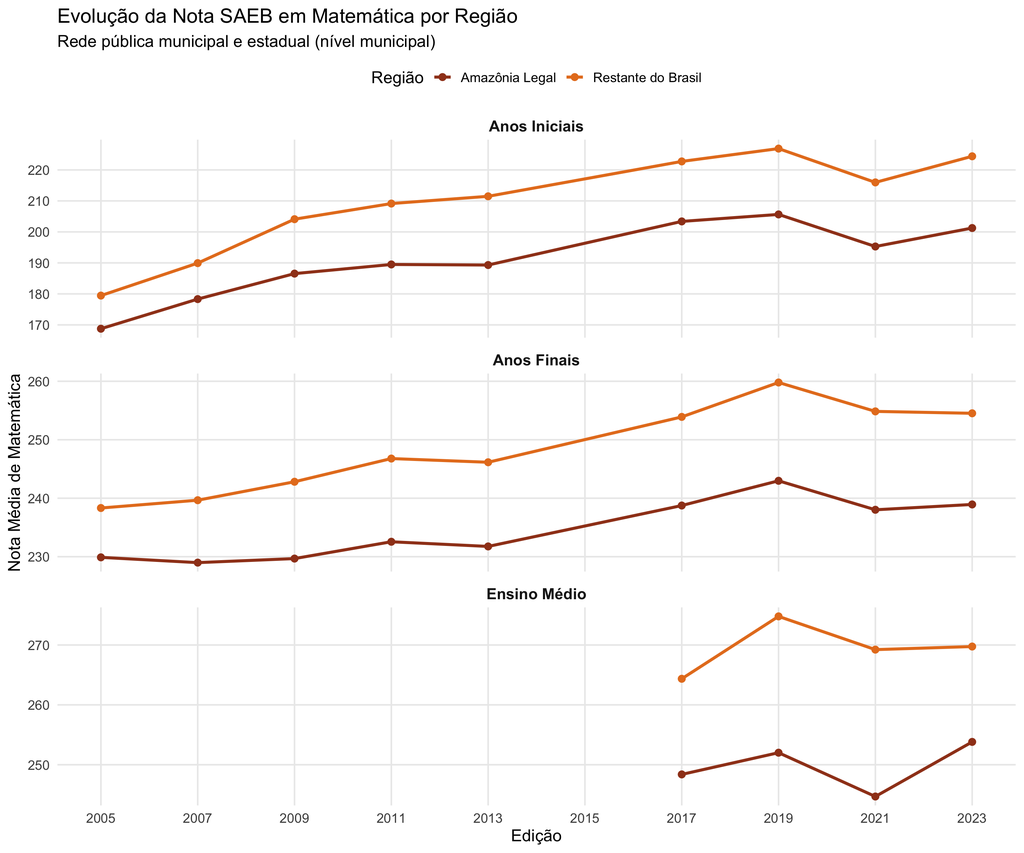

## Língua Portuguesa

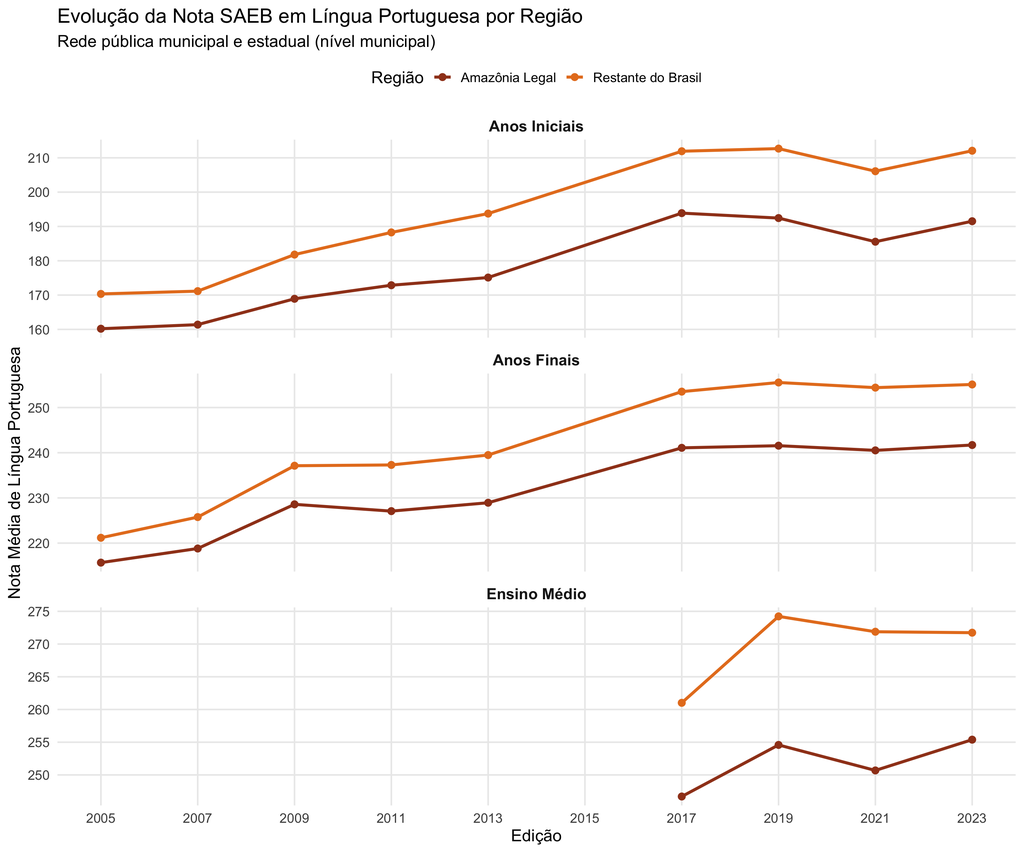

# Aprovação Escolar

## Taxas de Aprovação 2023

Tabela 21 - Taxa de aprovação 2023 por etapa e região (rede pública)

| Etapa | Aprovação Média AL | Aprovação Média RB | Diferença | Mediana AL | Mediana RB | N AL | N RB |
| --- | --- | --- | --- | --- | --- | --- | --- |
| Anos Iniciais | 96,0% | 97,3% | ▼ -1,3% | 97,5% | 98,7% | 919 | 5.609 |
| Anos Finais | 93,5% | 93,0% | ▲ +0,5% | 95,6% | 95,2% | 944 | 6.120 |
| Ensino Médio | 94,0% | 91,4% | ▲ +2,5% | 95,6% | 93,2% | 773 | 4.776 |

## Aprovação por UF

Tabela 22 - Taxa de aprovação 2023 por UF: Anos Iniciais

| UF | Aprovação Média | Diferença vs. RB | Municípios |
| --- | --- | --- | --- |
| AP | 88,9% | ▼ -8,5% | 21 |
| PA | 92,4% | ▼ -4,9% | 161 |
| AC | 94,1% | ▼ -3,2% | 32 |
| AM | 94,7% | ▼ -2,6% | 118 |
| RR | 95,0% | ▼ -2,3% | 15 |
| RO | 96,1% | ▼ -1,2% | 65 |
| TO | 96,9% | ▼ -0,4% | 150 |
| Restante do Brasil | 97,3% | ● +0,0% | 5.609 |
| MA | 97,3% | ▲ +0,0% | 182 |
| MT | 99,4% | ▲ +2,1% | 175 |

Tabela 23 - Taxa de aprovação 2023 por UF: Anos Finais

| UF | Aprovação Média | Diferença vs. RB | Municípios |
| --- | --- | --- | --- |
| AP | 86,5% | ▼ -6,5% | 21 |
| PA | 88,6% | ▼ -4,3% | 171 |
| AC | 90,5% | ▼ -2,4% | 30 |
| RR | 91,1% | ▼ -1,8% | 17 |
| AM | 91,3% | ▼ -1,6% | 113 |
| MA | 92,9% | ▼ -0,0% | 184 |
| Restante do Brasil | 93,0% | ● +0,0% | 6.120 |
| RO | 96,1% | ▲ +3,1% | 69 |
| TO | 96,1% | ▲ +3,1% | 175 |
| MT | 98,6% | ▲ +5,6% | 164 |

Tabela 24 - Taxa de aprovação 2023 por UF: Ensino Médio

| UF | Aprovação Média | Diferença vs. RB | Municípios |
| --- | --- | --- | --- |
| AP | 84,9% | ▼ -6,5% | 16 |
| AC | 85,9% | ▼ -5,5% | 22 |
| AM | 87,5% | ▼ -4,0% | 62 |
| RR | 87,6% | ▼ -3,8% | 15 |
| Restante do Brasil | 91,4% | ● +0,0% | 4.776 |
| MA | 92,4% | ▲ +1,0% | 183 |
| RO | 92,9% | ▲ +1,4% | 52 |
| TO | 95,0% | ▲ +3,6% | 137 |
| MT | 96,1% | ▲ +4,7% | 141 |
| PA | 98,8% | ▲ +7,4% | 145 |

# Síntese Comparativa

## Indicadores Consolidados

Tabela 25 - Síntese comparativa de indicadores do IDEB 2023

| Indicador | Amazônia Legal | Restante do Brasil | Diferença | Comparação |
| --- | --- | --- | --- | --- |
| **IDEB Observado 2023** |  |  |  |  |
| IDEB 2023: Anos Iniciais | 5,09 | 5,95 | ▼ -0,86 |  |
| IDEB 2023: Anos Finais | 4,39 | 4,83 | ▼ -0,44 |  |
| IDEB 2023: Ensino Médio | 3,84 | 4,20 | ▼ -0,36 |  |
| **Notas SAEB 2023** |  |  |  |  |
| SAEB Matemática: Anos Iniciais | 201,25 | 224,40 | ▼ -23,15 |  |
| SAEB Língua Portuguesa: Anos Iniciais | 191,52 | 212,06 | ▼ -20,54 |  |
| SAEB Matemática: Anos Finais | 238,93 | 254,52 | ▼ -15,59 |  |
| SAEB Língua Portuguesa: Anos Finais | 241,71 | 255,11 | ▼ -13,40 |  |
| SAEB Matemática: Ensino Médio | 253,81 | 269,74 | ▼ -15,93 |  |
| SAEB Língua Portuguesa: Ensino Médio | 255,39 | 271,73 | ▼ -16,35 |  |
| **Indicador de Rendimento 2023** |  |  |  |  |
| Fluxo (P): Anos Iniciais | 0,96 | 0,97 | ▼ -0,01 |  |
| Fluxo (P): Anos Finais | 0,94 | 0,93 | ▲ +0,01 |  |
| Fluxo (P): Ensino Médio | 0,94 | 0,92 | ▲ +0,02 |  |

**Interpretação:** Valores negativos (seta vermelha) indicam que a Amazônia Legal apresenta desempenho inferior ao Restante do Brasil no indicador correspondente. O IDEB varia de 0 a 10, sendo que a meta nacional é atingir 6,0 nos Anos Iniciais.

# Metodologia

Tabela 26 - Fontes de dados utilizadas neste relatório

| Fonte | Ano | Nível | Arquivo | Variáveis principais |
| --- | --- | --- | --- | --- |
| IDEB - Anos Iniciais (Municípios) | 2023 (série 2005-2023) | Municipal (por rede) | divulgacao_anos_iniciais_municipios_2023.xlsx | IDEB observado (10 edições), notas SAEB (Mat/Port), taxas de aprovação, metas projetadas |
| IDEB - Anos Finais (Municípios) | 2023 (série 2005-2023) | Municipal (por rede) | divulgacao_anos_finais_municipios_2023.xlsx | IDEB observado (10 edições), notas SAEB (Mat/Port), taxas de aprovação, metas projetadas |
| IDEB - Ensino Médio (Municípios) | 2023 (série 2005-2023) | Municipal (por rede) | divulgacao_ensino_medio_municipios_2023.xlsx | IDEB observado (4 edições), notas SAEB (Mat/Port), taxas de aprovação, metas projetadas |
| IDEB - Anos Iniciais (Escolas) | 2023 (série 2005-2023) | Escola | divulgacao_anos_iniciais_escolas_2023.xlsx | IDEB por escola, notas SAEB, taxas de aprovação (10 edições) |
| IDEB - Anos Finais (Escolas) | 2023 (série 2005-2023) | Escola | divulgacao_anos_finais_escolas_2023.xlsx | IDEB por escola, notas SAEB, taxas de aprovação (10 edições) |
| IDEB - Ensino Médio (Escolas) | 2023 (série 2005-2023) | Escola | divulgacao_ensino_medio_escolas_2023.xlsx | IDEB por escola, notas SAEB, taxas de aprovação (4 edições) |

**Notas metodológicas:**

1. **Classificação territorial:** A Amazônia Legal é definida pelos 772 municípios classificados pelo IBGE, distribuídos em AC, AM, AP, MA, MT, PA, RO, RR e TO. A classificação é feita pelo código IBGE de 7 dígitos (CO_MUNICIPIO).
2. **Filtro de rede:** Apenas dados da rede pública foram utilizados (Municipal, Estadual e Federal). A rede privada foi excluída de todas as análises.
3. **Tratamento de dados ausentes:** Valores “-” e “ND” nos arquivos originais foram tratados como dados ausentes (NA) e excluídos dos cálculos de médias e medianas.
4. **IDEB = N x P:** O Índice de Desenvolvimento da Educação Básica é calculado como o produto da Nota Média Padronizada do SAEB (N, escala 0 a 10) pelo Indicador de Rendimento (P, escala 0 a 1, derivado das taxas de aprovação).
5. **Período de referência:** Os dados abrangem todas as edições do IDEB de 2005 a 2023 para Anos Iniciais e Anos Finais, e de 2017 a 2023 para o Ensino Médio (que foi incluído no IDEB a partir de 2017).
6. **Metas projetadas:** As metas do 1º ciclo do IDEB (2007-2021) foram estabelecidas pelo MEC/INEP com base no IDEB observado em 2005 (ou 2017 para o Ensino Médio), com incrementos bienais.